# Estudios de Informática, Multimedia y Telecomunicaciones

## 6.2 Exercici 2

### 6.2.1 Es genera de nou el model no supervisat anterior, però usant una mètrica de distància diferent.

### 6.2.2 Es mostren i comenten les mesures de qualitat del model generat.

### 6.2.3 Addicionalment es comparen els dos models no supervisats amb mètriques de distància diferents.

### 6.2.4 S’interpreten els resultats i comenten les conclusions.

En aquest model no supervisat usaré el mètode Manhattan, abans, però, escalaré les dades normalitzades per poder-les fer servir.

```r
abaloneFinal_scale <- scale(abaloneFinalNor)
abalone_manh <- dist(abaloneFinal_scale, method = 'manhattan')
hcabalone<- hclust(abalone_manh, method = "ward.D2")
```

Usem el model i visualitzem els diferents valors pels diferents clusters:

```r
library(dendextend)
```

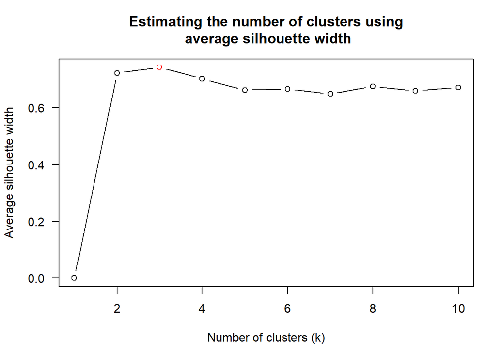

```r
dendabalone <- as.dendrogram(hcabalone)
dend_k<- find_k(dendabalone)
plot(dend_k)
```

Veiem que el millor nombre de clusters és 3. Visualitzem els grups comparant-los amb les dades reals.

```r
hcabalone_clusters <- cutree(hcabalone, k = 3)
table(hcabalone_clusters)
```

```
## hcabalone_clusters
##    1    2    3
## 1284  947 1942
```

```r
table( abaloneSet$Sex)
```

```
##
##    F    I    M
## 1305 1342 1526
```

```r
table(hcabalone_clusters, abaloneSet$Sex)
```

```
##
## hcabalone_clusters    F    I    M
##                  1  359  498  427
##                  2   20  835   92
##                  3  926    9 1007
```

Veiem que hi ha molta dispersió de dades, i en el cluster 1 hi ha elements del sexe femení, masculí i infantil.

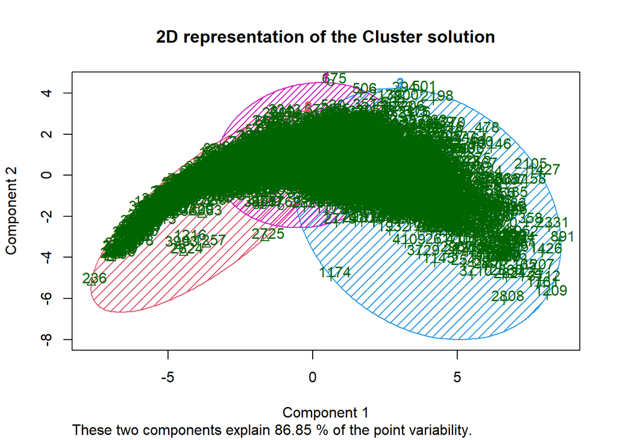

```r
clusplot(abaloneFinal_scale, hcabalone_clusters, main='2D representation of the Cluster solution',
color=TRUE, shade=TRUE,
labels=2, lines=0)
```

En comparació amb el model k-means, veiem els clusters més separats però com hem vist a la matriu de confussió hi havia valors del sexe I F M en el mateix cluster de forma igual, cosa que ens diu que no ens serveix per separar les dades.

## 6.3 Exercici 3

### 6.3.1 S’apliquen els algorismes DBSCAN i OPTICS de forma correcta.

### 6.3.2 Es proven, descriuen i interpreten els resultats amb diferents valors d’eps.

### 6.3.3 S’obté una mesura de com és de bo l’agrupament.

### 6.3.4 Es comparen els resultats obtinguts dels models anteriors i DBSCAN.

### 6.3.5 Es comenten les conclusions.

### 6.3.6 Identifica quines possibles limitacions tenen les dades que has seleccionat per obtenir conclusions amb els models utilitzats (no supervisats).

Usaré el model DBSCAN, que genera grups segons la densitat del registres. Utilitzarem les dades d’abaloneFinalNor per determinar el millor valro d’epsilon:

```r
if (!require('dbscan')) install.packages('dbscan'); library('dbscan')
dbscanAbalone<- dbscan(abaloneFinalNor, eps = 0.58 , minPts = 5)
dbscanAbalone
```

```
## DBSCAN clustering for 4173 objects.
## Parameters: eps = 0.58, minPts = 5
## Using euclidean distances and borderpoints = TRUE
## The clustering contains 2 cluster(s) and 0 noise points.
##
##    1    2
## 2831 1342
##
## Available fields: cluster, eps, minPts, dist, borderPoints
```

El model ens proposa 2 grups i cap mostra de soroll.

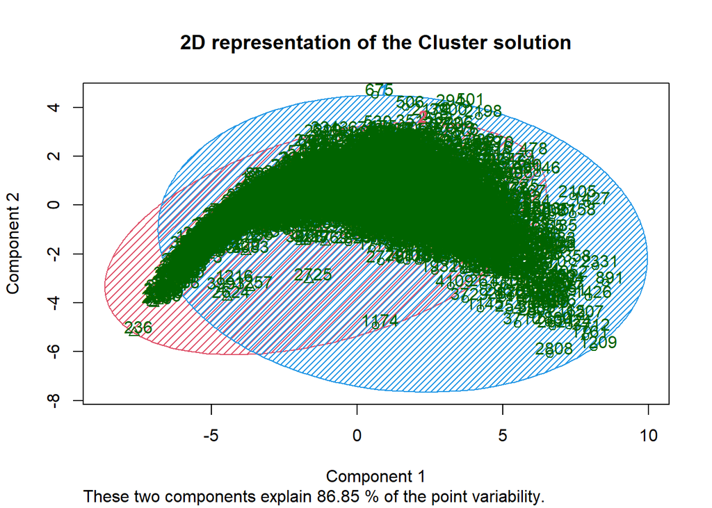

```r
clusplot(abaloneFinal_scale, dbscanAbalone$cluster, main='2D representation of the Cluster solution',
color=TRUE, shade=TRUE,
labels=2, lines=0)
```

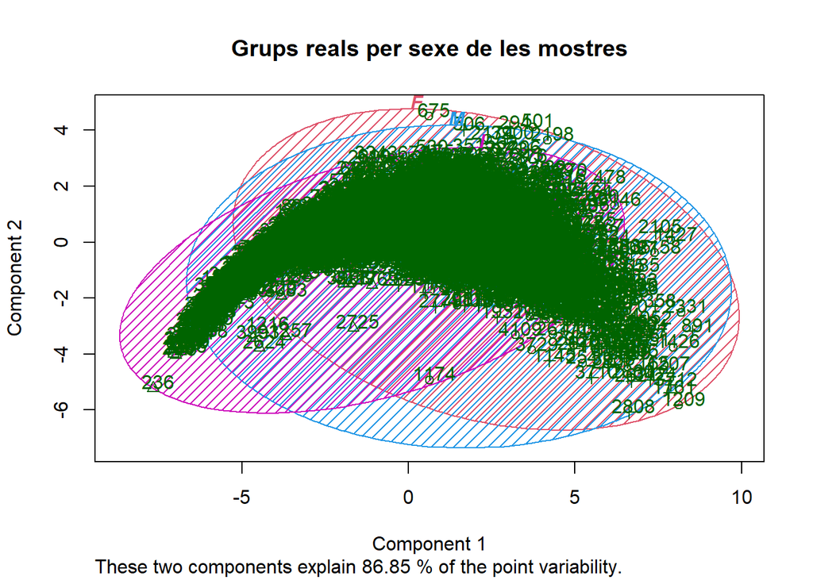

```r
clusplot(abaloneFinal_scale, abaloneSet$Sex, main='Grups reals per sexe de les mostres',
color=TRUE, shade=TRUE,
labels=2, lines=0)
```

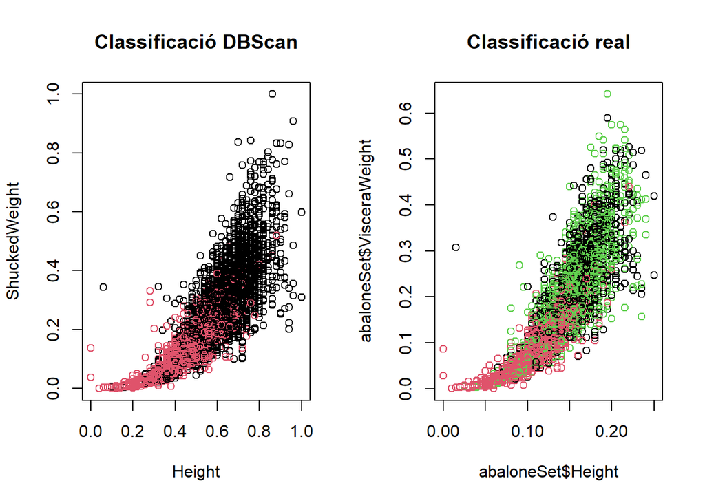

```r
old.par <- par(mfrow=c(1, 2))
plot(abaloneFinalnsp[c(3,5)], col=dbscanAbalone$cluster, main="Classificació DBScan")
plot(x = abaloneSet$Height, y = abaloneSet$VisceraWeight, col = as.factor(abaloneSet$Sex), main="Classificació real")
```

Veiem que novament DBScan classifica les dades en dos grups, coincidint entre el sexe infantil i sexe adult.

```r
table(dbscanAbalone$cluster, abaloneSet$Sex)
```

```
##
##        F    I    M
##   1 1305    0 1526
##   2    0 1342    0
```

Podem veure a la taula com ha identificat perfectament en el cluster 2 els abalons infantils i ha agrupat tots els abalons adults al cluster 1. Aquest model ha assolit un ajustament del 100% en identificar elsabalons infantils.

Apliquem ara el model Optics per identificar clusters.

```r
abaloneOptics <- optics(abaloneFinalNor,minPts = 10)
abaloneOptics
```

```
## OPTICS ordering/clustering for 4173 objects.
## Parameters: minPts = 10, eps = 0.62779140873019, eps_cl = NA, xi = NA
## Available fields: order, reachdist, coredist, predecessor, minPts, eps,
##                   eps_cl, xi
```

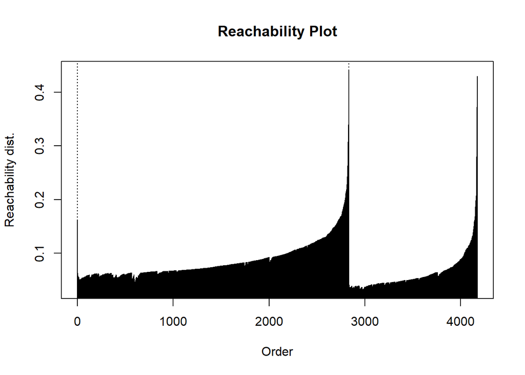

```r
plot(abaloneOptics)
```

Observant el diagrama obtingut de de les dades ordenades segons el model Optics veiem dos grups clarament identificats. Els valors mes baixos equivalen a les zones més denses i properes al nucli, els valors més alts són els valors més allunyats del centre.

Apliquem de nou el model Optic amb diferent valor:

```r
abaloneOptics <- optics(abaloneFinalNor,minPts = 1)
abaloneOptics
```

```
## OPTICS ordering/clustering for 4173 objects.
## Parameters: minPts = 1, eps = 0.441151568493295, eps_cl = NA, xi = NA
## Available fields: order, reachdist, coredist, predecessor, minPts, eps,
##                   eps_cl, xi
```

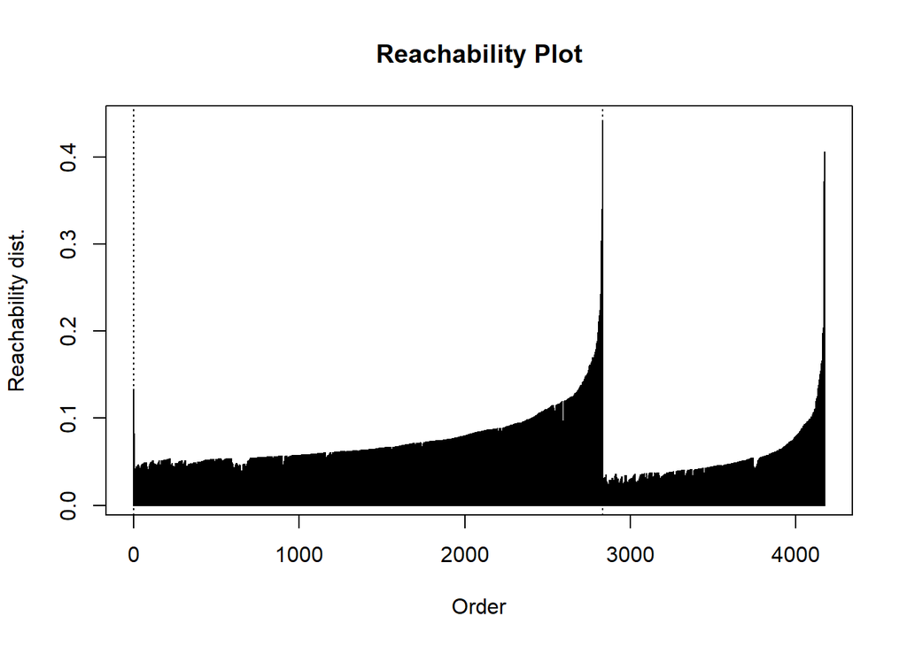

```r
plot(abaloneOptics)
```

Obtenim també dos grups ben diferenciats, igual que amb el valor minPts = 10.

## 6.4 Exercici 4

### 6.4.1 Es generen regles i es comenten i interpreten les més significatives.

### 6.4.2 Extraiem les regles del model en format text i gràfic.

### 6.4.3 Addicionalment es genera matriu de confusió per mesurar la capacitat predictiva de l’algorisme.

### 6.4.4 Es comparen i interpreten els resultats (sense i amb opcions de poda o boosting), explicant els avantatges i inconvenients del model generat respecte a un altre mètode de construcció.

### 6.4.5 S’avalua la taxa d’error a cada nivell d’arbre, l’eficiència en classificació (a les fases de training, validació i test) i la comprensibilitat.

### 6.4.6 S’interpreten i comenten les conclusions.

Usarem el model C50 per generar l’arbrede decisió.

```r
cols<- c("Sex")
for (i in cols){
abaloneFinal[,i] <- as.factor(abaloneFinal[,i])
}
```

Generaré un grup de dades aleatòries per l’entrenament.

```r
set.seed(60)
random <- abaloneFinal[sample(nrow(abaloneFinal)),]
y <- random[,1]
n = c(2,3,4,5,6,7,8,9,10,11,12)
X <- random[,n]
```

```r
split_prop <- 3
index = sample(1:nrow(abaloneFinal), size=floor(((split_prop-1)/split_prop)*nrow(abaloneFinal)))
trainX<-X[index,]
trainy<-y[index]
testX<-X[-index,]
testy<-y[-index]
```

Observem les dades extretes aeatòriament per evitar classificacions esbiaixades:

```r
summary(trainX)
```

```
##      Length          Diameter          Height        WholeWeight
##  Min.   :0.0750   Min.   :0.0550   Min.   :0.0000   Min.   :0.0020
##  1st Qu.:0.4550   1st Qu.:0.3500   1st Qu.:0.1150   1st Qu.:0.4512
##  Median :0.5450   Median :0.4250   Median :0.1450   Median :0.8023
##  Mean   :0.5255   Mean   :0.4089   Mean   :0.1396   Mean   :0.8351
##  3rd Qu.:0.6150   3rd Qu.:0.4800   3rd Qu.:0.1650   3rd Qu.:1.1603
##  Max.   :0.8000   Max.   :0.6300   Max.   :0.2500   Max.   :2.5550
##  ShuckedWeight    VisceraWeight     ShellWeight         Rings
##  Min.   :0.0010   Min.   :0.0005   Min.   :0.0015   Min.   : 1.000
##  1st Qu.:0.1911   1st Qu.:0.0955   1st Qu.:0.1326   1st Qu.: 8.000
##  Median :0.3360   Median :0.1715   Median :0.2350   Median : 9.000
##  Mean   :0.3617   Mean   :0.1820   Mean   :0.2410   Mean   : 9.932
##  3rd Qu.:0.5054   3rd Qu.:0.2554   3rd Qu.:0.3300   3rd Qu.:11.000
##  Max.   :1.3510   Max.   :0.6415   Max.   :0.8850   Max.   :29.000
##      Adult            PCAD1              PCAD2
##  Min.   :0.0000   Min.   :-6.53975   Min.   :-2.393327
##  1st Qu.:0.0000   1st Qu.:-1.78530   1st Qu.:-0.211851
##  Median :1.0000   Median : 0.12618   Median : 0.059836
##  Mean   :0.6743   Mean   : 0.03676   Mean   :-0.002777
##  3rd Qu.:1.0000   3rd Qu.: 1.84685   3rd Qu.: 0.298240
##  Max.   :1.0000   Max.   : 7.55809   Max.   : 1.558616
```

```r
summary(trainy)
```

```
##    F    I    M
##  860  906 1016
```

```r
summary(testX)
```

```
##      Length          Diameter          Height        WholeWeight
##  Min.   :0.1100   Min.   :0.0900   Min.   :0.0000   Min.   :0.0080
##  1st Qu.:0.4425   1st Qu.:0.3400   1st Qu.:0.1150   1st Qu.:0.4163
##  Median :0.5400   Median :0.4200   Median :0.1400   Median :0.7910
##  Mean   :0.5206   Mean   :0.4055   Mean   :0.1383   Mean   :0.8129
##  3rd Qu.:0.6100   3rd Qu.:0.4800   3rd Qu.:0.1650   3rd Qu.:1.1350
##  Max.   :0.8150   Max.   :0.6500   Max.   :0.2500   Max.   :2.8255
##  ShuckedWeight    VisceraWeight     ShellWeight         Rings
##  Min.   :0.0025   Min.   :0.0020   Min.   :0.0030   Min.   : 2.000
##  1st Qu.:0.1703   1st Qu.:0.0890   1st Qu.:0.1247   1st Qu.: 8.000
##  Median :0.3355   Median :0.1675   Median :0.2270   Median : 9.000
##  Mean   :0.3533   Mean   :0.1769   Mean   :0.2336   Mean   : 9.932
##  3rd Qu.:0.4963   3rd Qu.:0.2462   3rd Qu.:0.3200   3rd Qu.:11.000
##  Max.   :1.4880   Max.   :0.5750   Max.   :0.8970   Max.   :23.000
##      Adult            PCAD1              PCAD2
##  Min.   :0.0000   Min.   :-6.08685   Min.   :-2.294953
##  1st Qu.:0.0000   1st Qu.:-1.99463   1st Qu.:-0.229191
##  Median :1.0000   Median : 0.03381   Median : 0.065296
##  Mean   :0.6866   Mean   :-0.07351   Mean   : 0.005555
##  3rd Qu.:1.0000   3rd Qu.: 1.75255   3rd Qu.: 0.288732
##  Max.   :1.0000   Max.   : 7.80073   Max.   : 1.792213
```

```r
summary(testy)
```

```
##   F   I   M
## 445 436 510
```

Es verifica que l’extracció és equilibrada ja que hi ha mostres dels 3 sexes i uns valors de les demès variables raonables.

Procedeixo a crear l’arbre de decisió:

```r
trainy = as.factor(trainy)
arbreDecisio <- C50::C5.0(trainX, trainy,rules=TRUE )
arbreDecisio
```

```
##
## Call:
## C5.0.default(x = trainX, y = trainy, rules = TRUE)
##
## Rule-Based Model
## Number of samples: 2782
## Number of predictors: 11
##
## Number of Rules: 2
##
## Non-standard options: attempt to group attributes
```

```r
summary(arbreDecisio)
```

```
##
## Call:
## C5.0.default(x = trainX, y = trainy, rules = TRUE)
##
##
## C5.0 [Release 2.07 GPL Edition]      Wed Jan 25 23:43:20 2023
## -------------------------------
##
## Class specified by attribute `outcome'
##
## Read 2782 cases (12 attributes) from undefined.data
##
## Rules:
##
## Rule 1: (906, lift 3.1)
##  Adult <= 0
##  ->  class I  [0.999]
##
## Rule 2: (1876/860, lift 1.5)
##  Adult > 0
##  ->  class M  [0.542]
##
## Default class: M
##
##
## Evaluation on training data (2782 cases):
##
##          Rules
##    ----------------
##      No      Errors
##
##       2  860(30.9%)   <<
##
##
##     (a)   (b)   (c)    <-classified as
##    ----  ----  ----
##                 860    (a): class F
##           906          (b): class I
##                1016    (c): class M
##
##
##  Attribute usage:
##
##  100.00% Adult
##
##
## Time: 0.0 secs
```

Veiem que ens surt un arbre molt bàsic,però això és perquè no s’ha eliminat la columna adult, repetim el procés eliminant la columna adult.

```r
cols<- c("Sex")
for (i in cols){
abaloneFinal[,i] <- as.factor(abaloneFinal[,i])
}
```

```r
set.seed(60)
#random <- abaloneFinal[sample(nrow(abaloneFinal)),]
random <-random[,-10, -11]
y <- random[,1]
n = c(2,3,4,5,6,7,8,9)
X <- random[,n]
```

```r
split_prop <- 3
index = sample(1:nrow(abaloneFinal), size=floor(((split_prop-1)/split_prop)*nrow(abaloneFinal)))
trainX<-X[index,]
trainy<-y[index]
testX<-X[-index,]
testy<-y[-index]
```

```r
summary(trainX)
```

```
##      Length          Diameter         Height        WholeWeight
##  Min.   :0.0750   Min.   :0.055   Min.   :0.0000   Min.   :0.0020
##  1st Qu.:0.4500   1st Qu.:0.350   1st Qu.:0.1150   1st Qu.:0.4401
##  Median :0.5400   Median :0.420   Median :0.1400   Median :0.7843
##  Mean   :0.5221   Mean   :0.406   Mean   :0.1387   Mean   :0.8192
##  3rd Qu.:0.6150   3rd Qu.:0.480   3rd Qu.:0.1650   3rd Qu.:1.1405
##  Max.   :0.8150   Max.   :0.650   Max.   :0.2500   Max.   :2.8255
##  ShuckedWeight    VisceraWeight     ShellWeight         Rings
##  Min.   :0.0010   Min.   :0.0005   Min.   :0.0015   Min.   : 1.000
##  1st Qu.:0.1846   1st Qu.:0.0925   1st Qu.:0.1300   1st Qu.: 8.000
##  Median :0.3322   Median :0.1670   Median :0.2288   Median : 9.000
##  Mean   :0.3550   Mean   :0.1785   Mean   :0.2369   Mean   : 9.924
##  3rd Qu.:0.4984   3rd Qu.:0.2494   3rd Qu.:0.3250   3rd Qu.:11.000
##  Max.   :1.2530   Max.   :0.5900   Max.   :0.8970   Max.   :29.000
```

```r
summary(trainy)
```

```
##    F    I    M
##  866  911 1005
```

```r
summary(testX)
```

```
##      Length          Diameter          Height       WholeWeight
##  Min.   :0.1100   Min.   :0.0900   Min.   :0.025   Min.   :0.0080
##  1st Qu.:0.4500   1st Qu.:0.3500   1st Qu.:0.115   1st Qu.:0.4460
##  Median :0.5500   Median :0.4300   Median :0.145   Median :0.8225
##  Mean   :0.5273   Mean   :0.4113   Mean   :0.140   Mean   :0.8447
##  3rd Qu.:0.6200   3rd Qu.:0.4850   3rd Qu.:0.165   3rd Qu.:1.1775
##  Max.   :0.7800   Max.   :0.6300   Max.   :0.240   Max.   :2.6570
##  ShuckedWeight    VisceraWeight     ShellWeight         Rings
##  Min.   :0.0025   Min.   :0.0020   Min.   :0.0030   Min.   : 3.000
##  1st Qu.:0.1890   1st Qu.:0.0950   1st Qu.:0.1313   1st Qu.: 8.000
##  Median :0.3415   Median :0.1765   Median :0.2400   Median :10.000
##  Mean   :0.3667   Mean   :0.1840   Mean   :0.2418   Mean   : 9.947
##  3rd Qu.:0.5058   3rd Qu.:0.2587   3rd Qu.:0.3300   3rd Qu.:11.000
##  Max.   :1.4880   Max.   :0.6415   Max.   :0.7800   Max.   :27.000
```

```r
summary(testy)
```

```
##   F   I   M
## 439 431 521
```

```r
trainy = as.factor(trainy)
arbreDecisio <- C50::C5.0(trainX, trainy,rules=TRUE )
arbreDecisio
```

```
##
## Call:
## C5.0.default(x = trainX, y = trainy, rules = TRUE)
##
## Rule-Based Model
## Number of samples: 2782
## Number of predictors: 8
##
## Number of Rules: 24
##
## Non-standard options: attempt to group attributes
```

```r
summary(arbreDecisio)
```

```
##
## Call:
## C5.0.default(x = trainX, y = trainy, rules = TRUE)
##
##
## C5.0 [Release 2.07 GPL Edition]      Wed Jan 25 23:43:21 2023
## -------------------------------
##
## Class specified by attribute `outcome'
##
## Read 2782 cases (9 attributes) from undefined.data
##
## Rules:
##
## Rule 1: (8, lift 2.9)
##  Length > 0.53
##  Height > 0.145
##  Height <= 0.16
##  VisceraWeight > 0.1545
##  VisceraWeight <= 0.162
##  ->  class F  [0.900]
##
## Rule 2: (6, lift 2.8)
##  Height <= 0.115
##  WholeWeight <= 0.9445
##  ShellWeight > 0.192
##  Rings > 11
##  ->  class F  [0.875]
##
## Rule 3: (4, lift 2.7)
##  Diameter > 0.605
##  ->  class F  [0.833]
##
## Rule 4: (33/7, lift 2.5)
##  WholeWeight > 0.524
##  ShuckedWeight <= 0.272
##  VisceraWeight <= 0.1545
##  ShellWeight <= 0.212
##  Rings > 11
##  ->  class F  [0.771]
```

[output cut: 139 more lines]

```
##
##
##  Attribute usage:
##
##   99.50% Rings
##   97.05% VisceraWeight
##   79.51% ShellWeight
##   50.43% ShuckedWeight
##   15.17% WholeWeight
##   12.94% Length
##    5.97% Diameter
##    1.73% Height
##
##
## Time: 0.0 secs
```

Ens han sortit diverserser regles per determinar el sexe i observem una regla que és del 90% per identificar abalons femenins adults:

Repetim el procés però només per crear un arbre per identificar els adults.

```r
cols<- c("Adult")
for (i in cols){
abaloneFinal[,i] <- as.factor(abaloneFinal[,i])
}
```

```r
set.seed(60)
random <- abaloneFinal[sample(nrow(abaloneFinal)),]
random <-random[]
```

Eliminem columna de Sexe:

```r
random <-random[,-1]
```

Eliminem les columnes PCAD

```r
random <-random[,-10]
random <-random[,-10]
```

Eliminem la columna Rings ja que volem veure si hi ha alguna regla que ens permeti determinar l’edat dels abalons sense haver de comptar els anells.

```r
random <-random[,-8]
```

```r
y <- random[,8]
n = c(1,2,3,4,5,6,7)
X <- random[,n]
```

```r
split_prop <- 3
index = sample(1:nrow(abaloneFinal), size=floor(((split_prop-1)/split_prop)*nrow(abaloneFinal)))
trainX<-X[index,]
trainy<-y[index]
testX<-X[-index,]
testy<-y[-index]
```

```r
summary(trainX)
```

```
##      Length          Diameter          Height        WholeWeight
##  Min.   :0.0750   Min.   :0.0550   Min.   :0.0000   Min.   :0.0020
##  1st Qu.:0.4550   1st Qu.:0.3500   1st Qu.:0.1150   1st Qu.:0.4512
##  Median :0.5450   Median :0.4250   Median :0.1450   Median :0.8023
##  Mean   :0.5255   Mean   :0.4089   Mean   :0.1396   Mean   :0.8351
##  3rd Qu.:0.6150   3rd Qu.:0.4800   3rd Qu.:0.1650   3rd Qu.:1.1603
##  Max.   :0.8000   Max.   :0.6300   Max.   :0.2500   Max.   :2.5550
##  ShuckedWeight    VisceraWeight     ShellWeight
##  Min.   :0.0010   Min.   :0.0005   Min.   :0.0015
##  1st Qu.:0.1911   1st Qu.:0.0955   1st Qu.:0.1326
##  Median :0.3360   Median :0.1715   Median :0.2350
##  Mean   :0.3617   Mean   :0.1820   Mean   :0.2410
##  3rd Qu.:0.5054   3rd Qu.:0.2554   3rd Qu.:0.3300
##  Max.   :1.3510   Max.   :0.6415   Max.   :0.8850
```

```r
summary(trainy)
```

```
##    0    1
##  906 1876
```

```r
summary(testX)
```

```
##      Length          Diameter          Height        WholeWeight
##  Min.   :0.1100   Min.   :0.0900   Min.   :0.0000   Min.   :0.0080
##  1st Qu.:0.4425   1st Qu.:0.3400   1st Qu.:0.1150   1st Qu.:0.4163
##  Median :0.5400   Median :0.4200   Median :0.1400   Median :0.7910
##  Mean   :0.5206   Mean   :0.4055   Mean   :0.1383   Mean   :0.8129
##  3rd Qu.:0.6100   3rd Qu.:0.4800   3rd Qu.:0.1650   3rd Qu.:1.1350
##  Max.   :0.8150   Max.   :0.6500   Max.   :0.2500   Max.   :2.8255
##  ShuckedWeight    VisceraWeight     ShellWeight
##  Min.   :0.0025   Min.   :0.0020   Min.   :0.0030
##  1st Qu.:0.1703   1st Qu.:0.0890   1st Qu.:0.1247
##  Median :0.3355   Median :0.1675   Median :0.2270
##  Mean   :0.3533   Mean   :0.1769   Mean   :0.2336
##  3rd Qu.:0.4963   3rd Qu.:0.2462   3rd Qu.:0.3200
##  Max.   :1.4880   Max.   :0.5750   Max.   :0.8970
```

```r
summary(testy)
```

```
##   0   1
## 436 955
```

```r
trainy = as.factor(trainy)
arbreDecisio <- C50::C5.0(trainX, trainy,rules=TRUE )
arbreDecisio
```

```
##
## Call:
## C5.0.default(x = trainX, y = trainy, rules = TRUE)
##
## Rule-Based Model
## Number of samples: 2782
## Number of predictors: 7
##
## Number of Rules: 5
##
## Non-standard options: attempt to group attributes
```

```r
summary(arbreDecisio)
```

```
##
## Call:
## C5.0.default(x = trainX, y = trainy, rules = TRUE)
##
##
## C5.0 [Release 2.07 GPL Edition]      Wed Jan 25 23:43:21 2023
## -------------------------------
##
## Class specified by attribute `outcome'
##
## Read 2782 cases (8 attributes) from undefined.data
##
## Rules:
##
## Rule 1: (57/12, lift 2.4)
##  Length > 0.505
##  VisceraWeight <= 0.1295
##  ShellWeight <= 0.267
##  ->  class 0  [0.780]
##
## Rule 2: (1285/503, lift 1.9)
##  VisceraWeight <= 0.16
##  ->  class 0  [0.608]
##
## Rule 3: (177/70, lift 1.9)
##  Length > 0.505
##  Height > 0.12
##  VisceraWeight <= 0.16
##  ShellWeight <= 0.267
##  ->  class 0  [0.603]
##
## Rule 4: (40/3, lift 1.3)
##  Length <= 0.505
##  ShellWeight > 0.213
##  ShellWeight <= 0.267
##  ->  class 1  [0.905]
##
## Rule 5: (1877/283, lift 1.3)
##  WholeWeight > 0.521
##  VisceraWeight > 0.112
```

[output cut: 16 more lines]

```
##    ----  ----
##     729   177    (a): class 0
##     343  1533    (b): class 1
##
##
##  Attribute usage:
##
##  100.00% VisceraWeight
##   68.30% ShellWeight
##   67.47% WholeWeight
##    8.27% Length
##    6.36% Height
##
##
## Time: 0.0 secs
```

Regla 1:

Mostrem l’arbre:

[figure not shown]

```r
arbreDecisioGrafic <- C50::C5.0(trainX, trainy)
suppressWarnings(plot(arbreDecisioGrafic))
```

Calculem la precisió de l’arbre:

```r
arbreDecisioPrediccio <- predict( arbreDecisio, testX, type="class" )
print(sprintf("La precisió de l'arbre és: %.4f %%",100*sum(arbreDecisioPrediccio == testy) /
length(arbreDecisioPrediccio)))
```

```
## [1] "La precisió de l'arbre és: 79.4393 %"
```

## 6.5 Exercici 5

### 6.5.1 Prova amb una variació o un altre enfocament algorítmic amb els algorismes vistos a l’assignatura.

### 6.5.2 Es detalla, comenta i avalua la qualitat de classificació.

### 6.5.3 Es comparen i comenten els resultats de manera exhaustiva amb el mètode de construcció anterior.

### 6.5.4 Identifica i comenta, quines possibles limitacions tenen les dades que has seleccionat per obtenir conclusions amb els models utilitzats (supervisat).

En aquesta part usaré el model supervisat RandomForest i ens servirà per comparar-ho amb el model C50 usat anteriorment.

```r
if(!require(randomForest)){
install.packages('randomForest', repos='http://cran.us.r-project.org')
library(randomForest)
}
set.seed(21)
abaloneFinalRForest <- abaloneFinal
#Eliminem columna de sexe
abaloneFinalRForest <-abaloneFinalRForest[,-1]
#Elimenm columnes PCAD1 i PCAD2
abaloneFinalRForest <-abaloneFinalRForest[,-10]
abaloneFinalRForest <-abaloneFinalRForest[,-10]
#Eliminem columna Rings
abaloneFinalRForest <-abaloneFinalRForest[,-8]
```

Dividim les dades en funció de la columna Adult:

```r
y <- abaloneFinalRForest[,8]
X <- abaloneFinalRForest[,1:7]
```

Separem les dades:

```r
set.seed(33)
split_prop <- 3
index = sample(1:nrow(abaloneFinalRForest), size=floor(((split_prop-1)/split_prop)*nrow(abaloneFinalRForest)))
trainX<-X[index,]
trainy<-y[index]
testX<-X[-index,]
testy<-y[-index]
```

Visualitzem la divisió de les dades:

```r
summary(trainX)
```

```
##      Length          Diameter          Height        WholeWeight
##  Min.   :0.1100   Min.   :0.0900   Min.   :0.0000   Min.   :0.0080
##  1st Qu.:0.4500   1st Qu.:0.3450   1st Qu.:0.1113   1st Qu.:0.4353
##  Median :0.5400   Median :0.4200   Median :0.1400   Median :0.7843
##  Mean   :0.5213   Mean   :0.4056   Mean   :0.1382   Mean   :0.8162
##  3rd Qu.:0.6138   3rd Qu.:0.4800   3rd Qu.:0.1650   3rd Qu.:1.1382
##  Max.   :0.8150   Max.   :0.6500   Max.   :0.2500   Max.   :2.8255
##  ShuckedWeight    VisceraWeight     ShellWeight
##  Min.   :0.0025   Min.   :0.0005   Min.   :0.0030
##  1st Qu.:0.1815   1st Qu.:0.0905   1st Qu.:0.1250
##  Median :0.3305   Median :0.1685   Median :0.2270
##  Mean   :0.3541   Mean   :0.1779   Mean   :0.2359
##  3rd Qu.:0.4954   3rd Qu.:0.2490   3rd Qu.:0.3250
##  Max.   :1.4880   Max.   :0.6415   Max.   :0.8970
```

```r
table(trainy)
```

```
## trainy
##    0    1
##  926 1856
```

```r
prop.table(table(trainy))
```

```
## trainy
##         0         1
## 0.3328541 0.6671459
```

```r
summary(testX)
```

```
##      Length         Diameter          Height        WholeWeight
##  Min.   :0.075   Min.   :0.0550   Min.   :0.0100   Min.   :0.0020
##  1st Qu.:0.455   1st Qu.:0.3500   1st Qu.:0.1150   1st Qu.:0.4547
##  Median :0.550   Median :0.4300   Median :0.1450   Median :0.8275
##  Mean   :0.529   Mean   :0.4121   Mean   :0.1409   Mean   :0.8506
##  3rd Qu.:0.620   3rd Qu.:0.4850   3rd Qu.:0.1700   3rd Qu.:1.1838
##  Max.   :0.770   Max.   :0.6100   Max.   :0.2350   Max.   :2.5550
##  ShuckedWeight    VisceraWeight     ShellWeight
##  Min.   :0.0010   Min.   :0.0005   Min.   :0.0015
##  1st Qu.:0.1895   1st Qu.:0.0975   1st Qu.:0.1350
##  Median :0.3465   Median :0.1725   Median :0.2400
##  Mean   :0.3685   Mean   :0.1853   Mean   :0.2437
##  3rd Qu.:0.5178   3rd Qu.:0.2570   3rd Qu.:0.3335
##  Max.   :1.2455   Max.   :0.5750   Max.   :0.7100
```

Creem l’arbre:

```r
set.seed(21)
abaloneFinalRForestAplicado=randomForest(trainX , trainy, ntree=500)
abaloneFinalRForestAplicado
```

```
##
## Call:
##  randomForest(x = trainX, y = trainy, ntree = 500)
##                Type of random forest: classification
##                      Number of trees: 500
## No. of variables tried at each split: 2
##
##         OOB estimate of  error rate: 17.29%
## Confusion matrix:
##     0    1 class.error
## 0 667  259   0.2796976
## 1 222 1634   0.1196121
```

Observem que l’error aproximat és de 17,29% a la hora de classificar els abalone.

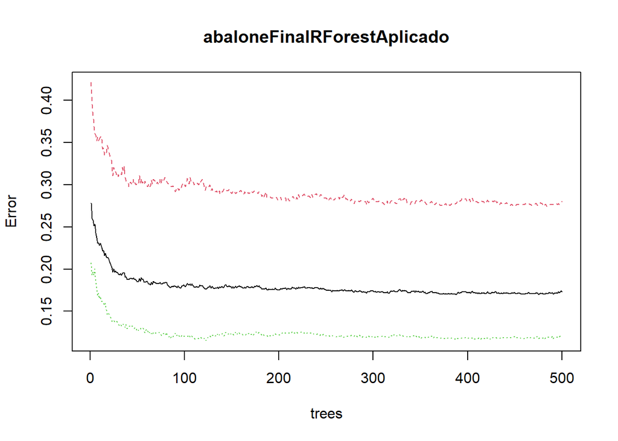

```r
plot(abaloneFinalRForestAplicado)
```

Podem veure que a mesura que augmenten el nombre d’arbres de decisió creats l’error és més baix però s’estabilitza als 50 aprox.

## 6.6 Exercici 6

### 6.6.1 S’identifiquen possibles riscos de l’ús del model (mínim 300 paraules).

En aquesta pràctica hem usat models supervisats i models no supervisats.  
L’aprenentatge supervisat és un mètode d’aprenentatge automàtic definit mitjançant l’ús conjunt de dades etiquetades. Aquests conjunts de dades estan dissenyats per entrenar o supervisar Algorismes que classifiquen les dades o prediuen amb més o menys precisió uns resultats. Un cop etiquetat, el model pot mesurar la seva precisió i aprendre amb el temps. Se sol usar aquest model per classificar dades.  
L’aprenentatge no supervisat utilitza algorismes d’aprenentatge automàtic per analitzar i agrupar col·leccions de dades sense etiquetar, és a dir, que no sabem la seva classificació. Aquests algorismes poden descobrir patrons ocults a les dades sense necessitat de la intervenció humana (per això s’anomenen no-supervisades). Se solen fer ús aquests models per: agrupar i reduir la dimensionalitat de les dades.  
En aquesta pràctica hem fet servir ambdós models, però podem comprovar que els models no supervisats han sabut dividir els grups perfectament entre adults i infantils, els models supervisats també ho han fet però amb una precisió menor.  
No obstant això, els models no supervisats comporten una sèrie de limitacions:  
• Les dades d’entrenament irrellevants introduïdes a la funció poden donar resultats inexactes.  
• La preparació i el preprocessament de dades és un procés llarg que espot complicar.  
• La precisió es ressent quan s’introdueixen com a dades valors improbables i incomplets.  
• El model necessita característiques adequades (variables d’entrada) per entrenar el model. Si les dades no estan en el format idoni, el model pot ser imprecís.  
• L’entrenament d’un model supervisat requereix molt temps de càlcul precís i verídic.  
Els models supervisats també tenen certes limitacions:  
• No disposem d’informació precisa sobre l’ordenació de les dades i la sortida de les dades utilitzades.  
• El resultat té una precisió menor perquè les dades d’entrada són desconegudes i sense etiquetar.  
• Les classes que ofereix el model no sempre es corresponen amb les classes que es requereixen.  
• Els usuaris s’han de dedicar a explicar i etiquetar les classes que segueixen la taxonomia creada pel model.

## 6.7 Exercici 7

### 6.7.1 Què he après en aquesta pràctica, quines limitacions he observat i com ho he solucionat (mínim 300 paraules).

En aquesta pràctica he après a treballar amb models supervisats i no-supervisats i he vist les diferents maneres de treballar de cadascun. Concretament en aquest dataSet usat he tingut més problemes a l’hora d’usar les funcions dels models supervisats, i crec que em sortien més errors, ja que són algorismes més complexos que els no-supervisats, si mes no per la part de seleccionar un subSet de dades per entrenar.  
A l’hora de comparar resultats he pogut comprovar que calcular la precisió dels models no supervisats és més fàcil que els models supervisats. La majoria d’errors els he solucionat consultant la documentació d’R, especialment per dubtes tècnics i mirant altres anàlisis fetes.  
A l’inici del curs no havia tingut cap experiència amb models de mineria de dades i havia treballat poc amb R. A mesura que avançava l’assignatura m’anava informant de la ciència de dades i alguna vegada, sense buscar-ho, m’apareixia per Internet algun vídeo o article sobre la ciència de dades. Concretament a la feina on treballo es va desenvolupar un algorisme que fos capaç de detectar el cel i el terra de les fotos i també els ocells, avions i puntes dels gratacels de les fotos. Aquest model es volia fer servir per a un prototip de dron amb conducció autònoma. Es va fer gràcies a Azure Machine Learning i vaig col·laborar en entrenar el model i marcar a les imatges els elements de les fotos. En aquest cas vam usar un model supervisat i vam fer servir un dataset d’imatges per poder entrenar el model i detectar finalment els elements d’un vídeo.  
Cada dia va cobrant més importància la ciència de dades, especialment amb el BigData, però ja és avui dia una de les ciències més poderoses i més valorades de les empreses, que fan ús l’anàlisi de dades per desplegar models d’intel·ligència artificial, entre ells un que ha adquirit una gran importància, ChatGTP.